# Statistical inference with the GSS data

## Setup

### Load packages

```r
library(ggplot2)
library(dplyr)
library(statsr)
```

### Load data

```r
load("gss.Rdata")
```

## Part 1: Data

The data set used in this exercise comes from the General Social Survey (GSS).$^1$ The target population of the GSS is adults (18+) living in households in the United States and speaking either English or Spanish.

- **Generalizability**: households are randomly sampled, therefore the results generalize to the US adult population living in households and speaking either English or Spanish.
- **Causality**: there is no random assignment, therefore it is not possible to infer causality relations between two variables.

## Part 2: Research question

The amount of public spending on space exploration (and related research activities) is often a controversial subject. In fact, many people think that money should be spent on more urgent and *down-to-earth* matters. It may be argued that it takes a given level of education to appreciate the importance of space exploration. It is therefore interesting to investigate if there is a significant difference in opinion towards space exploration spending depending on people’s education level.

## Part 3: Exploratory data analysis

To carry out the investigation, we will concentrate on two variables present in the database. The first is the categorical variable *degree*, which represents the educational attainment. It has the following levels:

- Less than (Lt) High School
- High School
- Junior College
- Bachelor
- Graduate

The second variable of interest is also categorical and is called *natspac*. It has the following three levels, representing the opinion of the interviewees about the space exploration budget:

- Too Little
- About Right
- Too Much

For the time being, we are not interested in studying how the correlation between these variables varies in time. We will therefore analyse only 2012 survey data.

```r
# Select only 2012 data
gss12 <- gss %>% filter(year == "2012")
```

For a preliminary analysis, we can calculate the proportions of the *natspac* variable levels grouped by the educational attainment. The results are summarised in the following table.

```r
# Output table with proportions
natspac2012 <- gss12 %>%
  filter(degree != "NA") %>%
  filter(natspac != "NA") %>%
  group_by(degree, natspac) %>%
  summarise(count = n()) %>%
  mutate(percent = count / sum(count))

natspac2012
```

```
## # A tibble: 15 x 4
## # Groups:   degree [5]
##    degree         natspac     count percent
##    <fct>          <fct>       <int>   <dbl>
##  1 Lt High School Too Little      8  0.0684
##  2 Lt High School About Right    50  0.427
##  3 Lt High School Too Much       59  0.504
##  4 High School    Too Little     92  0.209
##  5 High School    About Right   202  0.459
##  6 High School    Too Much      146  0.332
##  7 Junior College Too Little     19  0.247
##  8 Junior College About Right    30  0.390
##  9 Junior College Too Much       28  0.364
## 10 Bachelor       Too Little     52  0.323
## 11 Bachelor       About Right    68  0.422
## 12 Bachelor       Too Much       41  0.255
## 13 Graduate       Too Little     31  0.307
## 14 Graduate       About Right    49  0.485
## 15 Graduate       Too Much       21  0.208
```

The same data can be represented in a bar plot of the proportions of *natspac* for an easier comparison across the various *degree* levels.

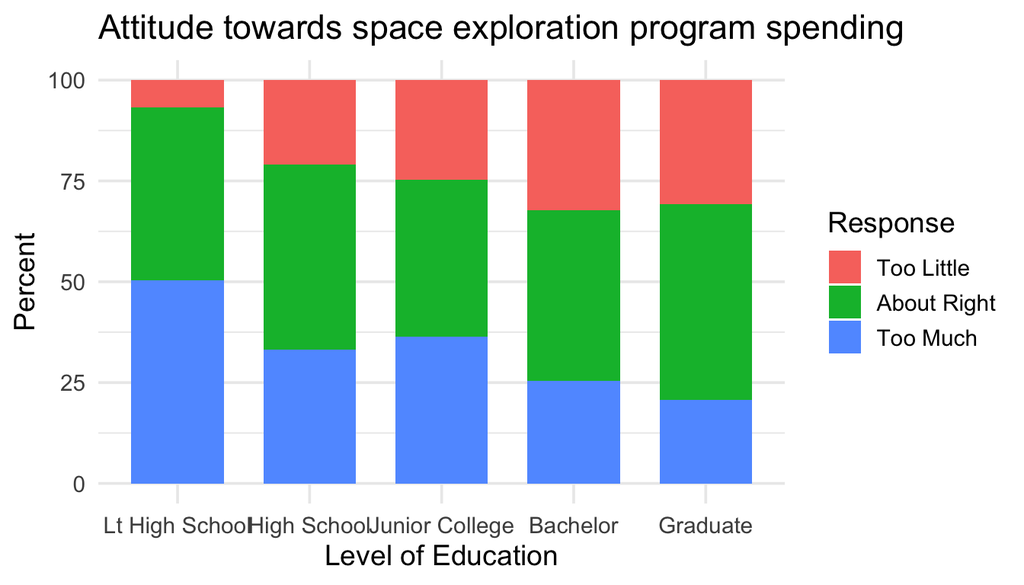

```r
ggplot(natspac2012, aes(x = factor(degree), y = percent*100, fill = factor(natspac))) +
  geom_bar(stat="identity", width = 0.7) +
  labs(x = "Level of Education", y = "Percent", fill = "Response") +
  theme_minimal(base_size = 14)+ggtitle("Attitude towards space exploration program spending")
```

Interestingly, the proportion of people that think that the spending on space exploration is “About Right” varies little with the educational attainment. On the contrary, the proportion of people who think that there is “Too Much” investment decreases with the educational level in favor of those who consider that it is “Too Little”. For this reason, we can create a new categorical variable called *too_much*, which takes the value “Yes” if the response is “Too Much”, “No” otherwise. The proportion of people thinking that there is “Too Much” spending on space exploration noticeably decreases among those who have a college degree. For this reason we will create a new categorical variable called *college* which takes the value “Degree” if *degree* is equal to “Bachelor” or “Graduate”, “No Degree” otherwise.

```r
# Get rid of NA values
gss12 <- gss12 %>% filter(degree != "NA") %>% filter(natspac != "NA")

# Create new variables
list1 <- list("Bachelor","Graduate")
gss12 <- gss12 %>% mutate(college = ifelse(degree %in% list1, "Degree", "No Degree"))
gss12 <- gss12 %>% mutate(too_much = ifelse(natspac == "Too Much" , "Yes", "No"))
```

The distribution of these two variables can be easily represented in a table.

```r
tab1 <- gss12 %>%
  group_by(college, too_much) %>%
  summarise(count = n()) %>%
  mutate(percent = count / sum(count))

tab1
```

```
## # A tibble: 4 x 4
## # Groups:   college [2]
##   college   too_much count percent
##   <chr>     <chr>    <int>   <dbl>
## 1 Degree    No         200   0.763
## 2 Degree    Yes         62   0.237
## 3 No Degree No         401   0.632
## 4 No Degree Yes        233   0.368
```

It results that 23.7% of respondents with a college degree consider that America is spending too much on space exploration, whereas this percentage rises to 36.8% among the respondents without a college degree. Is this difference in the sample proportions merely due to chance? We can answer this question by means of statistical inference.

## Part 4: Inference

In this section, we will perform a hypothesis test and we will calculate a confidence interval for the difference between two population proportions based on the sample proportions calculated above. We take *too_much* as response variable and *college* as explanatory variable.

Starting from the hypothesis test, we take as null hypothesis $H_0: p_{Degree} = p_{No\ Degree}$, meaning that the population proportions of people who think that space exploration spending is too much are the same across educational level groups. The alternative hypothesis is two-sided, namely $H_A: p_{Degree} \neq p_{No\ Degree}$.

The first condition for the application of the Central Limit Theorem (CLT), is that the sample proportions are independent and that the observations in each of the two samples are independent as well. This condition is fulfilled due to the random sampling method discussed in Part 1. Secondly, we calculate the **pool proportion**, consistently with the null hypothesis, and we check that there are at least 10 successes and 10 failures in each sample.

```r
n = sum(tab1[3])
n1 = tab1[1,3] + tab1[2,3]
n2 = tab1[3,3] + tab1[4,3]
p_pool = (tab1[2,3] + tab1[4,3])/n
p_pool*n1
```

```
##      count
## 1 86.26116
```

```r
p_pool*n2
```

```
##      count
## 1 208.7388
```

```r
(1 - p_pool)*n1
```

```
##      count
## 1 175.7388
```

```r
(1 - p_pool)*n2
```

```
##      count
## 1 425.2612
```

The second condition for the application of the CLT in case of hypothesis testing is thus verified. We will reject the null hypothesis if the resulting *p-value* will be below the significance level $\alpha = 0.05$. The test can be performed by invoking the *inference* function:

```r
inference(y = too_much, x = college, data = gss12, statistic = "proportion",
          type = "ht", method = "theoretical", success = "Yes", null= 0,
          alternative = "twosided")
```

```
## Response variable: categorical (2 levels, success: Yes)
## Explanatory variable: categorical (2 levels)
## n_Degree = 262, p_hat_Degree = 0.2366
## n_No Degree = 634, p_hat_No Degree = 0.3675
## H0: p_Degree =  p_No Degree
## HA: p_Degree != p_No Degree
## z = -3.7917
## p_value = 1e-04
```

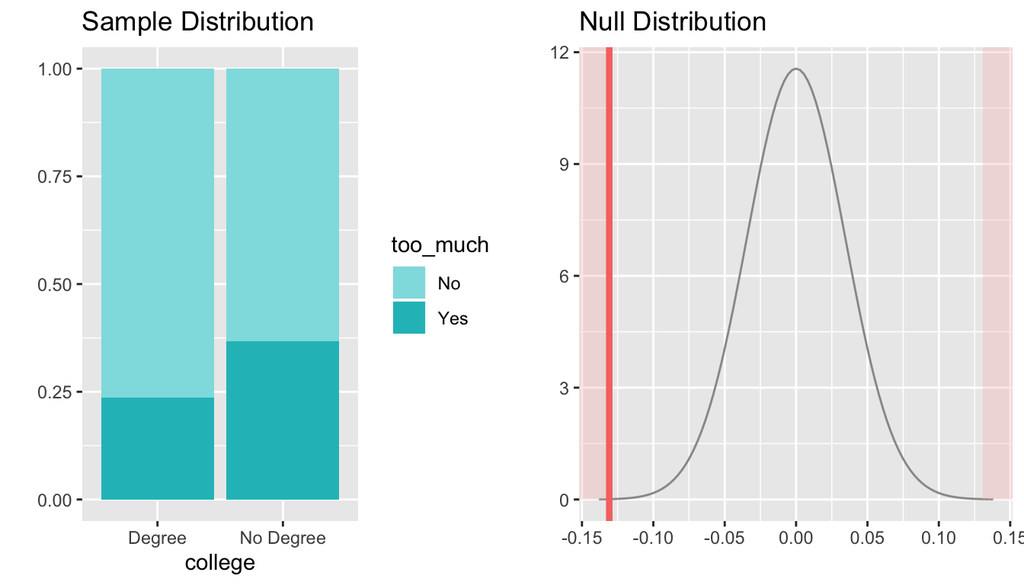

Since the *p-value* is below the value assumed for $\alpha$, the null hypothesis is rejected.

In order to verify the sample size condition for the calculation of the confidence interval with the CLT, we use the actual sample proportions. The table presented at the end of Part 3 shows that there are at least 10 successes and 10 failures in each samples. The 95% confidence interval is calculated as follows.

```r
inference(y = too_much, x = college, data = gss12, statistic = "proportion",
          type = "ci", method = "theoretical", success = "Yes",
          conf_level = 0.95)
```

```
## Response variable: categorical (2 levels, success: Yes)
## Explanatory variable: categorical (2 levels)
## n_Degree = 262, p_hat_Degree = 0.2366
## n_No Degree = 634, p_hat_No Degree = 0.3675
## 95% CI (Degree - No Degree): (-0.1946 , -0.0672)
```

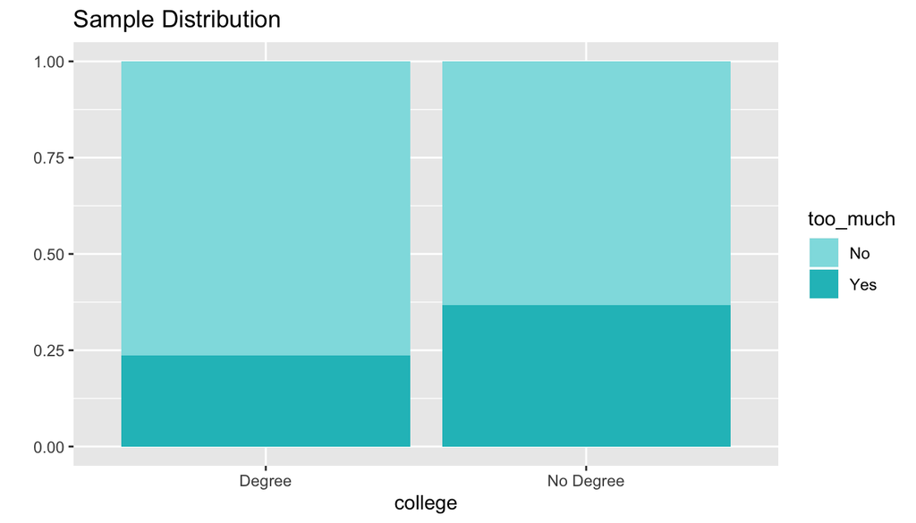

This result means that we are 95% confident that 19.5% to 6.7% **less** people with a college degree than without think that the money spent on space exploration is too much. Consistently with the result of the previous hypothesis test, this 95% confidence interval does not contain the null value.

## References

$^1$ Smith, Tom W., Michael Hout, and Peter V. Marsden. General Social Survey, 1972-2012 [Cumulative File]. ICPSR34802-v1. Storrs, CT: Roper Center for Public Opinion Research, University of Connecticut /Ann Arbor, MI: Inter-university Consortium for Political and Social Research [distributors], 2013-09-11. doi:10.3886/ICPSR34802.v1